# Análise dos furtos de celulares em grandes eventos públicos

21 de Junho de 2018

## Agenda

- Histórico
- Análise dos dados
- Machine Learning
- Conclusões

## Histórico

- Datasets da Secretaria de Segurança Pública do Estado de São Paulo: http://www.ssp.sp.gov.br/transparenciassp
- Início de um projeto pessoal: https://rimolive.github.io/mapa-crime-sp/

## Análise dos dados (1/3)

- **Crime**: furto de celular
- **Ano**: Entre 2014 e 2017
- **Cidade**: São Paulo

## Análise dos dados (2/3)

- Dimensões do dataset:
  - Linhas: 370537
  - Colunas: 53

## Análise dos dados (3/3)

- Uma breve descrição dos dados:

```
##  [1] "ANO_BO"                   "NUM_BO"
##  [3] "NUMERO_BOLETIM"           "BO_INICIADO"
##  [5] "BO_EMITIDO"               "DATAOCORRENCIA"
##  [7] "PERIDOOCORRENCIA"         "DATACOMUNICACAO"
##  [9] "DATAELABORACAO"           "BO_AUTORIA"
## [11] "FLAGRANTE"                "NUMERO_BOLETIM_PRINCIPAL"
## [13] "LOGRADOURO"               "NUMERO"
## [15] "BAIRRO"                   "CEP"
## [17] "CIDADE"                   "UF"
## [19] "LATITUDE"                 "LONGITUDE"
## [21] "DESCRICAOLOCAL"           "EXAME"
## [23] "SOLUCAO"                  "DELEGACIA_NOME"
## [25] "DELEGACIA_CIRCUNSCRICAO"  "ESPECIE"
## [27] "RUBRICA"                  "DESDOBRAMENTO"
## [29] "STATUS"                   "NOMEPESSOA"
## [31] "TIPOPESSOA"               "VITIMAFATAL"
## [33] "RG"                       "RG_UF"
## [35] "NATURALIDADE"             "NACIONALIDADE"
## [37] "SEXO"                     "DATANASCIMENTO"
## [39] "IDADE"                    "ESTADOCIVIL"
## [41] "PROFISSAO"                "GRAUINSTRUCAO"
## [43] "CORCUTIS"                 "NATUREZAVINCULADA"
## [45] "TIPOVINCULO"              "PLACA_VEICULO"
## [47] "UF_VEICULO"               "CIDADE_VEICULO"
## [49] "DESCR_COR_VEICULO"        "DESCR_MARCA_VEICULO"
## [51] "ANO_FABRICACAO"           "ANO_MODELO"
## [53] "DESCR_TIPO_VEICULO"
```

## Visualizações dos dados

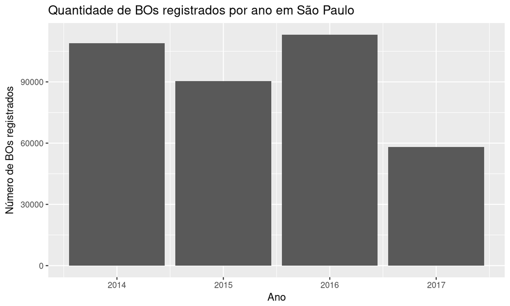

## Visualização dos dados

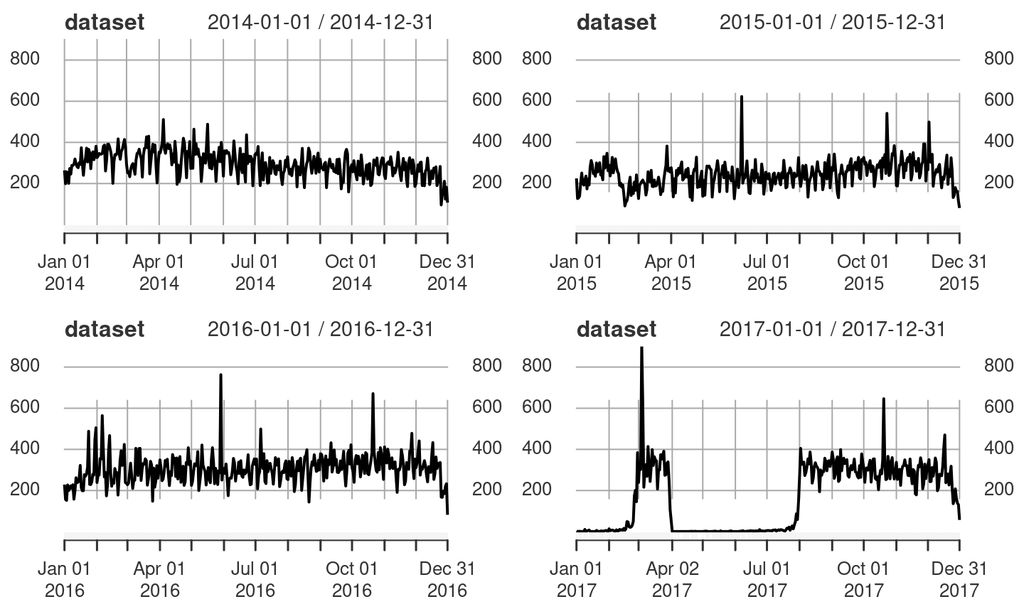

## Visualização dos dados

- Uma amostra de ~500 furtos registrados na cidade em 2014:

[interactive chart not shown]

## Será que os furtos de celulares ocorrem com mais frequência em grandes eventos?

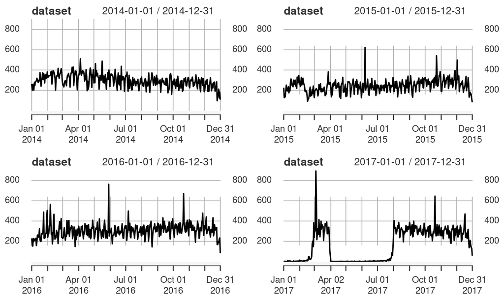

## É possível estimar o público de grandes eventos com base na quantidade de furtos de celular?

## Os eventos analisados

- Carnaval
- Parada Gay
- Marcha para Jesus
- Virada Cultural
- Virada Esportiva
- Copa do Mundo (Somente em 2014)

## Ferramentas Utlizadas

- Python para “scrapping” dos dados
- Linguagem R para análise dos dados
  - tidyverse
  - xts
  - leaflet
  - ggmap
- Biblioteca caret para Machine Learning

## Algoritmo utilizado

- Regressão Linear

## Resultados

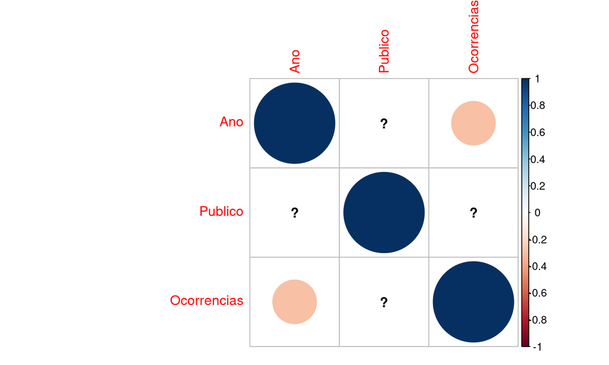

## Resultados

```
## Linear Regression
##
## 24 samples
##  3 predictor
##
## No pre-processing
## Resampling: Cross-Validated (10 fold)
## Summary of sample sizes: 22, 21, 21, 21, 22, 22, ...
## Resampling results:
##
##   RMSE     Rsquared   MAE
##   2320935  0.8817086  1829703
##
## Tuning parameter 'intercept' was held constant at a value of TRUE
```

## Resultados

```
##    ano            evento publico previsto
## 1 2016 Marcha para Jesus  340000  1320038
## 2 2016        Parada Gay 2000000  2107829
## 3 2016  Virada Esportiva 3500000  4600983
## 4 2017          Carnaval    7000  3260452
```

## Resultados

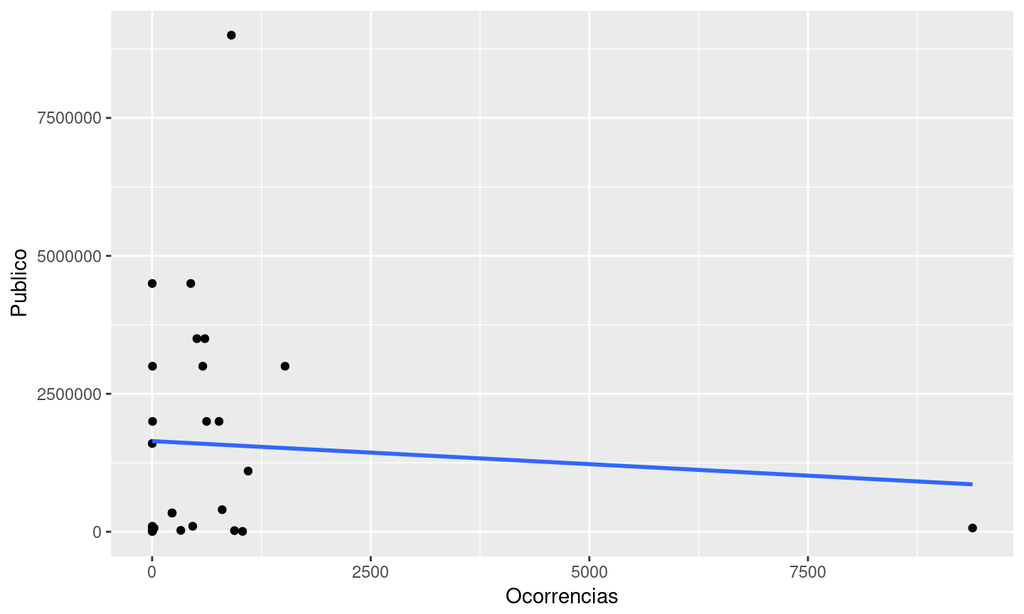

## Conclusões

- Os dados não permitem esboçar uma conclusão sobre as perguntas
  - Correlação não implica em causalidade
- Apesar dos poucos dados e muitos inexistentes, podemos ao menos inferir algo sobre eles
- O dados nos deram a oportunidade de aprender sobre as ferramentas

## Obrigado!

https://github.com/rimolive/relatorio-furto-sp